# Biscayne Bay-Cape Florida to Monroe County Line Aquatic Preserve

SEACAR Habitat Analyses

Last compiled on 10 June, 2026

# Funding & Acknowledgements

The data used in this analysis is from the Export Standardized Tables in the SEACAR Data Discovery Interface (DDI). Documents and information available through the SEACAR DDI are owned by the data provider(s) and users are expected to provide appropriate credit following accepted citation formats. Users are encouraged to access data to maximize utilization of gained knowledge, reducing redundant research and facilitating partnerships and scientific innovation.

With respect to documents and information available from SEACAR DDI, neither the State of Florida nor the Florida Department of Environmental Protection makes any warranty, expressed or implied, including the warranties of merchantability and fitness for a particular purpose arising out of the use or inability to use the data, or assumes any legal liability or responsibility for the accuracy, completeness, or usefulness of any information, apparatus, product, or process disclosed, or represents that its use would not infringe privately owned rights.

This report was funded in part, through a grant agreement from the Florida Department of Environmental Protection, Florida Coastal Management Program, by a grant provided by the Office for Coastal Management under the Coastal Zone Management Act of 1972, as amended, National Oceanic and Atmospheric Administration. The views, statements, findings, conclusions and recommendations expressed herein are those of the author(s) and do not necessarily reflect the views of the State of Florida, NOAA or any of their sub agencies.

**Published**: 2026-06-10

[figure not shown]

# Threshold Filtering

Threshold filters, following the guidance of Florida Department of Environmental Protection’s (*FDEP*) Division of Environmental Assessment and Restoration (*DEAR*) are used to exclude specific results values from the SEACAR Analysis. Based on the threshold filters, Quality Assurance / Quality Control (*QAQC*) Flags are inserted into the *SEACAR_QAQCFlagCode* and *SEACAR_QAQC_Description* columns of the export data. The *Include* column indicates whether the *QAQC* Flag will also indicate that data are excluded from analysis. No data are excluded from the data export, but the analysis scripts can use the *Include* column to exclude data (1 to include, 0 to exclude).

Continuous Water Quality threshold values

| *Parameter Name* | *Units* | *Low Threshold* | *High Threshold* |
| --- | --- | --- | --- |
| Chlorophyll a, Uncorrected for Pheophytin | ug/L | - | - |
| Dissolved Oxygen | mg/L | -0.000001 | 50 |
| Dissolved Oxygen Saturation | % | -0.000001 | 500 |
| Fluorescent Dissolved Organic Matter | QSE | - | - |
| Salinity | ppt | -0.000001 | 70 |
| Specific Conductivity | mS/cm | -0.000001 | 200 |
| Turbidity | NTU | -0.000001 | 4000 |
| Water Temperature | Degrees C | -5.000000 | 45 |
| pH | None | 2.000000 | 14 |

Discrete Water Quality threshold values

| *Parameter Name* | *Units* | *Low Threshold* | *High Threshold* |
| --- | --- | --- | --- |
| Ammonia, Un-ionized (NH3) | mg/L | - | - |
| Ammonium (NH4) | mg/L | - | - |
| Chlorophyll a, Corrected for Pheophytin | ug/L | - | - |
| Chlorophyll a, Uncorrected for Pheophytin | ug/L | - | - |
| Colored Dissolved Organic Matter | PCU | - | - |
| Dissolved Oxygen | mg/L | -0.000001 | 25 |
| Dissolved Oxygen Saturation | % | -0.000001 | 310 |
| Fluorescent Dissolved Organic Matter | QSE | - | - |
| Light Extinction Coefficient | m^-1 | - | - |
| NO2+3, Filtered | mg/L | - | - |
| Nitrate (NO3) | mg/L | - | - |
| Nitrite (NO2) | mg/L | - | - |
| Nitrogen, inorganic | mg/L | - | - |
| Nitrogen, organic | mg/L | - | - |
| Phosphate, Filtered (PO4) | mg/L | - | - |
| Salinity | ppt | -0.000001 | 70 |
| Secchi Depth | m | 0.000001 | 50 |
| Specific Conductivity | mS/cm | 0.005000 | 100 |
| Total Ammonia (N) | mg/L | - | - |
| Total Kjeldahl Nitrogen | mg/L | - | - |
| Total Nitrogen | mg/L | - | - |
| Total Nitrogen | mg/L | - | - |
| Total Phosphorus | mg/L | - | - |
| Total Suspended Solids | mg/L | - | - |
| Turbidity | NTU | - | - |
| Water Temperature | Degrees C | 3.000000 | 40 |
| pH | None | 2.000000 | 13 |

Quality Assurance Flags inserted based on threshold checks listed in Table 1 and 2

| *SEACAR QAQC Description* | *Include* | *SEACAR QAQCFlagCode* |
| --- | --- | --- |
| Exceeds maximum threshold | 0 | 2Q |
| Below minimum threshold | 0 | 4Q |
| Within threshold tolerance | 1 | 6Q |
| No defined thresholds for this parameter | 1 | 7Q |

# Value Qualifiers

Value qualifier codes included within the data are used to exclude certain results from the analysis. The data are retained in the data export files, but the analysis uses the *Include* column to filter the results.

**STORET and WIN value qualifier codes**

Value qualifier codes from *STORET* and *WIN* data are examined with the database and used to populate the *Include* column in data exports.

Value Qualifier codes excluded from analysis

| *Qualifier Source* | *Value Qualifier* | *Include* | *MDL* | *Description* |
| --- | --- | --- | --- | --- |
| STORET-WIN | H | 0 | 0 | Value based on field kit determination; results may not be accurate |
| STORET-WIN | J | 0 | 0 | Estimated value |
| STORET-WIN | V | 0 | 0 | Analyte was detected at or above method detection limit |
| STORET-WIN | Y | 0 | 0 | Lab analysis from an improperly preserved sample; data may be inaccurate |

**Discrete Water Quality Value Qualifiers**

The following value qualifiers are highlighted in the Discrete Water Quality section of this report. An exception is made for **Program 476** - *Charlotte Harbor Estuaries Volunteer Water Quality Monitoring Network* and data flagged with Value Qualifier **H** are included for this program only.

**H** - Value based on field kit determiniation; results may not be accurate. This code shall be used if a field screening test (e.g., field gas chromatograph data, immunoassay, or vendor-supplied field kit) was used to generate the value and the field kit or method has not been recognized by the Department as equivalent to laboratory methods.

**I** - The reported value is greater than or equal to the laboratory method detection limit but less than the laboratory practical quantitation limit.

**Q** - Sample held beyond the accepted holding time. This code shall be used if the value is derived from a sample that was prepared or analyzed after the approved holding time restrictions for sample preparation or analysis.

**S** - Secchi disk visible to bottom of waterbody. The value reported is the depth of the waterbody at the location of the Secchi disk measurement.

**U** - Indicates that the compound was analyzed for but not detected. This symbol shall be used to indicate that the specified component was not detected. The value associated with the qualifier shall be the laboratory method detection limit. Unless requested by the client, less than the method detection limit values shall not be reported

**Systemwide Monitoring Program (SWMP) value qualifier codes**

Value qualifier codes from the *SWMP* continuous program are examined with the database and used to populate the *Include* column in data exports. *SWMP* Qualifier Codes are indicated by *QualifierSource=SWMP*.

SWMP Value Qualifier codes

| *Qualifier Source* | *Value Qualifier* | *Include* | *Description* |
| --- | --- | --- | --- |
| SWMP | -1 | 1 | Optional parameter not collected |
| SWMP | -2 | 0 | Missing data |
| SWMP | -3 | 0 | Data rejected due to QA/QC |
| SWMP | -4 | 0 | Outside low sensor range |
| SWMP | -5 | 0 | Outside high sensor range |
| SWMP | 0 | 1 | Passed initial QA/QC checks |
| SWMP | 1 | 0 | Suspect data |
| SWMP | 2 | 1 | Reserved for future use |
| SWMP | 3 | 1 | Calculated data: non-vented depth/level sensorcorrection for changes in barometric pressure |
| SWMP | 4 | 1 | Historical: Pre-auto QA/QC |
| SWMP | 5 | 1 | Corrected data |

# Water Quality - Continuous

The following files were used in the continuous analysis:

- *Combined_WQ_WC_NUT_cont_Chlorophyll_a_Uncorrected_for_Pheophytin-2026-Mar-06.txt*
- *Combined_WQ_WC_NUT_cont_Dissolved_Oxygen-2026-Mar-06.txt*
- *Combined_WQ_WC_NUT_cont_Dissolved_Oxygen_Saturation-2026-Mar-06.txt*
- *Combined_WQ_WC_NUT_cont_Fluorescent_Dissolved_Organic_Matter-2026-Mar-06.txt*
- *Combined_WQ_WC_NUT_cont_pH-2026-Mar-06.txt*
- *Combined_WQ_WC_NUT_cont_Salinity-2026-Mar-06.txt*
- *Combined_WQ_WC_NUT_cont_Specific_Conductivity-2026-Mar-06.txt*
- *Combined_WQ_WC_NUT_cont_Turbidity-2026-Mar-06.txt*
- *Combined_WQ_WC_NUT_cont_Water_Temperature-2026-Mar-06.txt*

**Continuous monitoring locations in Biscayne Bay-Cape Florida to Monroe County Line Aquatic Preserve**

Station overview for Continuous parameters by Program

| ProgramID | ProgramLocationID | Years of Data | Use in Analysis | Parameters |
| --- | --- | --- | --- | --- |
| 986 | 6 | 11 | TRUE | Water Temperature |

**Program names:**

*986* - Water Temperature on Coral Reefs in the Florida Keys<sup>1</sup>

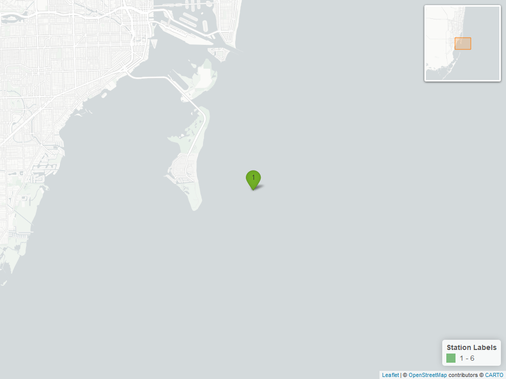

Map showing continuous water quality sampling locations within the boundaries of *Biscayne Bay-Cape Florida to Monroe County Line Aquatic Preserve*. Sites marked as *Use In Analysis* (green) are featured in this report.

### Water Temperature - Continuous

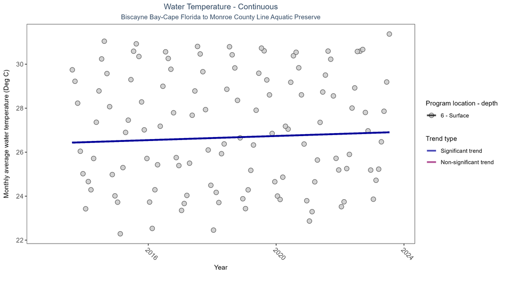

Scatter plot of monthly average water temperature over time at continuously monitored program locations. Each location is analyzed separately, with significant (blue) or non-significant (magenta) trend lines shown for time series that included five or more years of observations.

Seasonal Kendall-Tau Results for Water Temperature - All Stations

| Program Location | Statistical Trend | No. of Samples | No. Years with Data | Period of Record | Median Result Value | Tau | Sen Intercept | Sen Slope | P |
| --- | --- | --- | --- | --- | --- | --- | --- | --- | --- |
| 6 | Significantly increasing trend | 69753 | 11 | 2013 - 2023 | 26.84 | 0.19 | 26.41 | 0.05 | 0.01 |

At one program location, monthly average water temperature increased by 0.05°C per year.

# Coral Reef

The data file used is: **All_CORAL_Parameters-2026-Jun-04.txt**

**Percent Cover**

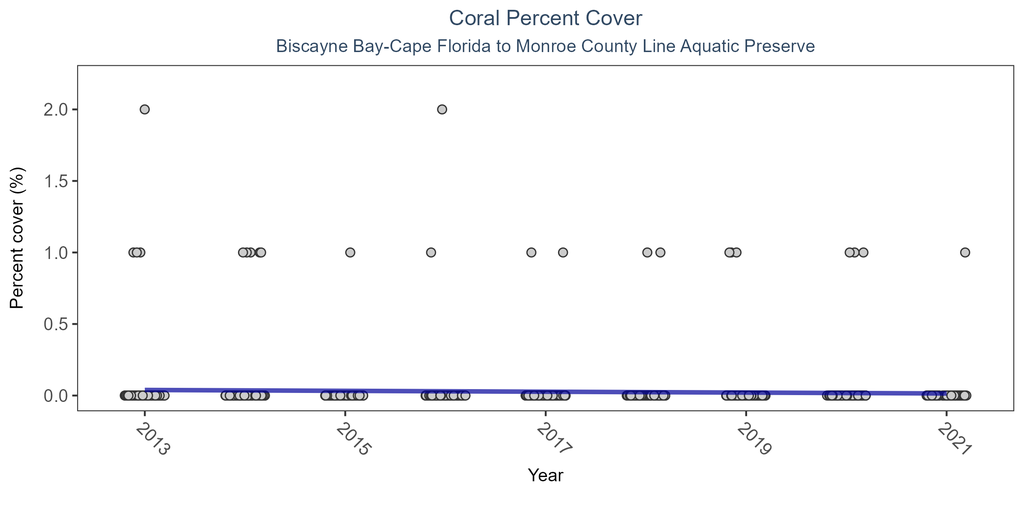

Coral Percent Cover

| Statistical Trend | Period of Record | LME Intercept | LME Slope | p |
| --- | --- | --- | --- | --- |
| No detectable trend | 2013 - 2021 | 6.16822 | -0.00304 | 0.16442 |

[figure not shown]

Map showing location of coral percent cover sampling locations within the boundaries of *Biscayne Bay-Cape Florida to Monroe County Line Aquatic Preserve*. The bubble size on the maps above reflect the amount of data available at each sampling site.

**Species Richness**

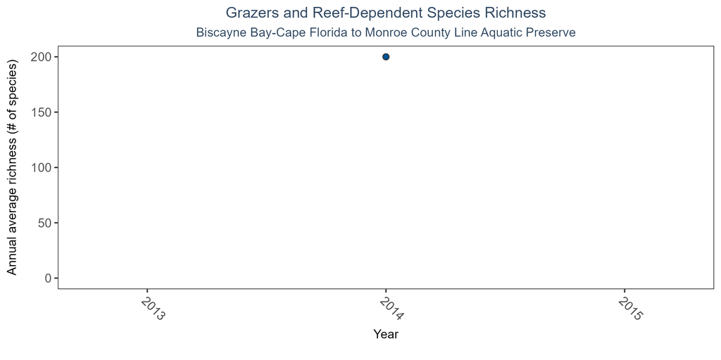

Line graph of annual average species richness of grazers and reef-dependent species over time. If the time series included more than one year of observations, a line connects the data points for visualization.

Coral Species Richness

| No. of Samples | No. Years with Data | Period of Record | Median No. of Taxa | Mean No. of Taxa |
| --- | --- | --- | --- | --- |
| 2 | 1 | 2014 - 2014 | 200 | 200 |

In the year 2014, 200 taxa were observed based on 2 observations.

[figure not shown]

Map showing location of coral species richness sampling locations within the boundaries of *Biscayne Bay-Cape Florida to Monroe County Line Aquatic Preserve*. The bubble size on the maps above reflect the amount of data available at each sampling site.

# Species list

| Abudefduf saxatilis<sup>1</sup> | Epinephelus morio<sup>1</sup> | Oculina diffusa<sup>2</sup> |
| --- | --- | --- |
| Acanthemblemaria aspera<sup>1</sup> | Epinephelus striatus<sup>1</sup> | Oculina sp. |
| Acanthemblemaria maria<sup>1</sup> | Eques lanceolatus<sup>1</sup> | Ocyurus chrysurus<sup>1</sup> |
| Acanthostracion polygonium<sup>1</sup> | Equetus punctatus<sup>1</sup> | Odontoscion dentex<sup>1</sup> |
| Acanthostracion quadricornis<sup>1</sup> | Eucinostomus argenteus | Ophioblennius macclurei<sup>1</sup> |
| Acanthurus bahianus<sup>1</sup> | Eusmilia fastigiata<sup>2</sup> | Opistognathus aurifrons |
| Acanthurus chirurgus<sup>1</sup> | Euthynnus alletteratus | Opistognathus macrognathus |
| Acanthurus coeruleus<sup>1</sup> | Favia fragum<sup>2</sup> | Opistognathus whitehursti |
| Acanthurus sp.<sup>1</sup> | Fistularia tabacaria<sup>1</sup> | Orbicella annularis<sup>2</sup> |
| Acropora cervicornis<sup>2</sup> | Gerres cinereus | Oxyurichthys stigmalophius<sup>1</sup> |
| Aetobatus narinari | Ginglymostoma cirratum | Parablennius marmoreus<sup>1</sup> |
| Agaricia agaricites<sup>2</sup> | Gnatholepis thompsoni<sup>1</sup> | Pareques acuminatus<sup>1</sup> |
| Agaricia fragilis<sup>2</sup> | Gobiosoma sp.<sup>1</sup> | Pareques umbrosus<sup>1</sup> |
| Agaricia lamarcki<sup>2</sup> | Gymnothorax funebris<sup>1</sup> | Pempheris schomburgkii<sup>1</sup> |
| Aluterus schoepfii<sup>1</sup> | Gymnothorax miliaris<sup>1</sup> | Pomacanthus arcuatus<sup>1</sup> |
| Aluterus scriptus<sup>1</sup> | Gymnothorax moringa<sup>1</sup> | Pomacanthus paru<sup>1</sup> |
| Aluterus sp.<sup>1</sup> | Gymnothorax vicinus<sup>1</sup> | Porifera |
| Amblycirrhitus pinos<sup>1</sup> | Haemulon album<sup>1</sup> | Porites astreoides<sup>2</sup> |
| Anisotremus surinamensis<sup>1</sup> | Haemulon aurolineatum<sup>1</sup> | Porites divaricata |
| Anisotremus virginicus<sup>1</sup> | Haemulon carbonarium<sup>1</sup> | Porites spp.<sup>2</sup> |
| Apogon binotatus<sup>1</sup> | Haemulon flavolineatum<sup>1</sup> | Priacanthus arenatus<sup>1</sup> |
| Apogon maculatus<sup>1</sup> | Haemulon macrostomum<sup>1</sup> | Prionotus ophryas<sup>1</sup> |
| Apogon pseudomaculatus<sup>1</sup> | Haemulon melanurum<sup>1</sup> | Prognathodes aculeatus<sup>1</sup> |
| Apogon townsendi<sup>1</sup> | Haemulon parra<sup>1</sup> | Pseudodiploria clivosa<sup>2</sup> |
| Archosargus probatocephalus<sup>1</sup> | Haemulon plumierii<sup>1</sup> | Pseudodiploria strigosa<sup>2</sup> |
| Archosargus rhomboidalis<sup>1</sup> | Haemulon sciurus<sup>1</sup> | Pseudupeneus maculatus<sup>1</sup> |
| Astrapogon sp.<sup>1</sup> | Haemulon sp.<sup>1</sup> | Ptereleotris calliura |
| Atherinomorus stipes | Haemulon striatum<sup>1</sup> | Ptereleotris helenae |
| Aulostomus maculatus<sup>1</sup> | Haemulon vittatum<sup>1</sup> | Pterois miles<sup>1</sup> |
| Azurina cyanea<sup>1</sup> | Halichoeres bivittatus<sup>1</sup> | Pterois volitans<sup>1</sup> |
| Balistes capriscus<sup>1</sup> | Halichoeres cyanocephalus<sup>1</sup> | Razorfish sp.<sup>1</sup> |

[output cut: 65 more lines]

1 - Coral Reef - Species Richness, 2 - Coral Reef - Percent Cover

# References

1.

Florida Fish and Wildlife Conservation Commision (FWC); Florida Wildlife Research Institute (FWRI). [Water Temperature on Coral Reefs in the Florida Keys](https://data.florida-seacar.org/programs/details/986). (2022).